# Week 8

Gaussian Mixture Models & EM

Canal Victor - Bourgeois Maxime - Buart Thibault - Budin Jacques - Blanchet Alexandre

# 8.4 EM using mclust

## GMM vs k-means

### Question 1

1. Download and import Data1 and Data2 . Plot both of the datasets on the same window. Color the observations with respect to the ground truth, like in Figure 8.6.

```r
#install.packages("mclust")
library(mclust)
data1 <- read.csv("data1.csv")
data2 <- read.csv("data2.csv")
head(data1)
```

```
##         X1         X2 truth
## 1 6.488267  0.2500645     4
## 2 2.521947 -2.6979865     3
## 3 3.068773 -2.9000760     3
## 4 4.314275  0.7029506     1
## 5 2.384499 -2.5356349     3
## 6 7.805410 -1.7029783     4
```

```r
head(data2)
```

```
##           X1         X2 truth
## 1  9.0650131  3.6693087     4
## 2 -0.2505132 -0.9810086     3
## 3  0.2121641 -0.8639544     3
## 4  6.7522538  2.9020410     1
## 5 -0.2161893 -0.9143583     3
## 6  8.1997291  2.6884910     4
```

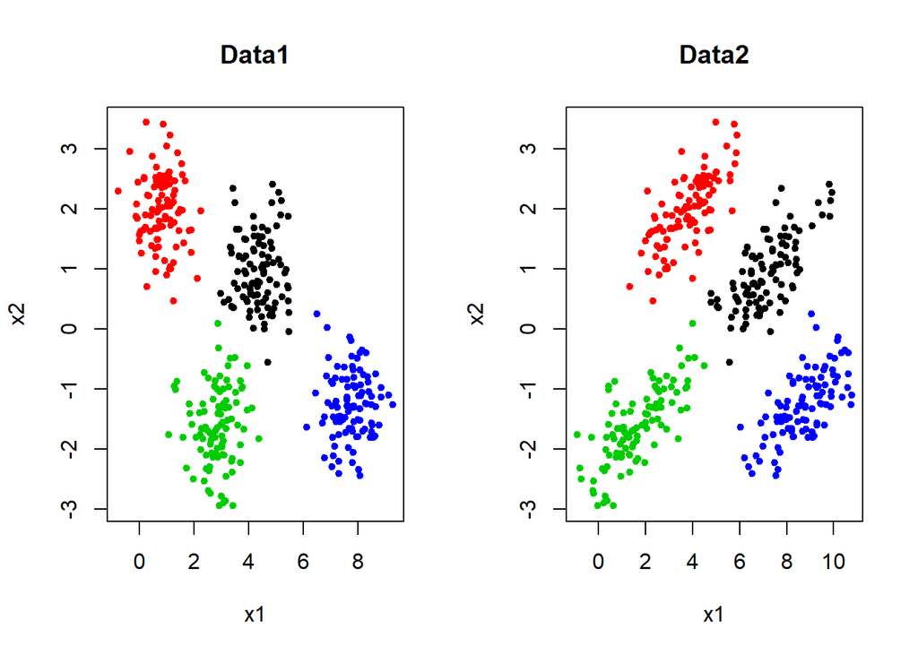

```r
par(mfrow=c(1,2))


plot(data1$X1, data1$X2, title("Data1"), xlab="x1", ylab="x2", col=data1$truth, pch=20)


plot(data2$X1, data1$X2, title("Data2"), xlab="x1", ylab="x2", col=data2$truth, pch=20)
```

### Question 2

2. Apply k -means on both datasets with 4 clusters. Plot both of the dataset on the same window and color the observations with respect to k -means results. Interpret the results.

```r
data1$truth <- NULL
data2$truth <- NULL


kmeanData1 <- kmeans(data1, iter.max = 20, centers = 4)
kmeanData2 <- kmeans(data2, iter.max = 20, centers = 4)

kmeanData1
```

```
## K-means clustering with 4 clusters of sizes 199, 52, 48, 101
##
## Cluster means:
##          X1         X2
## 1 3.6095139 -0.3450456
## 2 8.2236465 -1.1650103
## 3 7.2495526 -1.3815917
## 4 0.8651172  1.9604040
##
## Clustering vector:
##   [1] 3 1 1 1 1 3 4 1 1 4 2 4 4 1 1 4 1 4 1 1 1 1 3 1 1 3 3 1 1 4 1 1 1 1 1 2 4
##  [38] 1 4 1 1 3 4 1 4 3 4 4 4 3 2 2 1 2 3 1 1 4 4 1 4 4 4 4 1 1 4 1 1 3 1 1 1 3
##  [75] 4 1 1 1 3 1 1 1 4 2 1 1 1 1 1 4 1 4 1 1 1 3 1 4 4 4 3 4 1 1 1 2 1 2 4 1 1
## [112] 1 1 1 3 4 3 1 2 2 4 1 4 3 1 2 4 4 4 1 3 2 3 1 1 1 2 1 3 1 1 1 1 3 1 4 1 1
## [149] 4 1 4 1 4 1 2 1 4 1 1 1 1 1 2 1 1 2 4 4 1 3 2 2 2 4 4 4 1 1 1 2 1 2 1 1 2
## [186] 1 3 1 1 2 1 1 2 1 3 2 3 4 4 1 1 1 4 4 2 1 1 3 1 2 1 1 4 4 2 4 1 2 4 2 1 1
## [223] 2 1 1 1 4 3 1 3 1 1 1 1 3 4 1 4 1 1 4 1 1 2 4 1 3 1 4 1 1 4 1 1 2 3 1 1 4
## [260] 2 1 1 1 1 3 1 1 1 1 1 4 1 1 2 1 4 2 4 4 4 2 4 4 2 3 2 4 1 4 1 4 1 1 4 1 1
## [297] 4 4 1 1 3 3 1 2 4 4 1 3 2 4 4 1 2 1 4 1 4 3 1 1 4 1 1 1 1 2 1 2 4 1 3 4 3
## [334] 1 1 1 1 4 1 4 2 4 4 4 4 2 4 1 4 1 4 1 2 1 4 4 1 1 1 3 2 2 1 1 4 1 1 4 1 3
## [371] 1 1 1 1 3 1 2 3 1 3 1 2 1 1 1 1 3 3 3 3 1 2 1 4 4 1 1 4 1 4
##
## Within cluster sum of squares by cluster:
## [1] 585.83099  20.03962  22.13560  71.02517
##  (between_SS / total_SS =  81.3 %)
##
## Available components:
##
## [1] "cluster"      "centers"      "totss"        "withinss"     "tot.withinss"
## [6] "betweenss"    "size"         "iter"         "ifault"
```

```r
kmeanData2
```

```
## K-means clustering with 4 clusters of sizes 129, 105, 66, 100
##
## Cluster means:
##          X1         X2
## 1 8.7436482  3.3544047
## 2 3.2089072  1.5391349
## 3 0.9180885 -0.2502885
## 4 6.0481454  2.6606717
##
## Clustering vector:
##   [1] 1 3 3 4 3 1 2 4 3 2 1 2 1 3 2 4 3 2 4 2 2 3 4 1 1 4 1 4 1 4 4 1 3 1 2 1 2
##  [38] 1 2 4 3 1 2 4 2 1 2 2 2 1 1 1 3 1 1 3 4 2 2 3 2 4 4 4 4 3 2 4 2 1 2 4 3 1
##  [75] 4 2 4 3 4 2 2 1 2 1 1 3 3 4 3 4 3 4 4 2 2 1 1 2 2 4 1 2 4 1 3 1 1 1 4 3 3
## [112] 3 1 3 1 4 4 2 1 1 2 2 2 1 1 1 4 2 2 1 1 1 4 3 1 2 1 4 1 2 4 3 3 1 3 4 1 3
## [149] 2 3 2 1 2 4 1 3 2 3 2 3 4 3 1 2 3 1 2 2 3 1 1 1 1 2 3 4 4 2 4 1 1 1 3 4 1
## [186] 3 1 4 1 1 4 4 1 2 4 1 1 4 2 4 1 3 2 2 1 4 3 1 4 1 4 1 2 2 1 2 4 4 4 1 3 1
## [223] 1 3 2 3 2 1 1 1 1 3 1 1 1 2 2 4 4 3 2 4 4 1 2 4 1 4 2 3 3 2 3 1 1 4 1 4 2
## [260] 1 4 2 3 3 4 4 4 4 1 4 2 1 4 1 3 2 1 2 4 4 1 2 2 1 1 1 4 4 2 1 2 2 1 4 3 1
## [297] 2 2 4 3 1 1 4 1 4 2 4 1 1 4 2 1 1 1 2 1 2 4 2 2 4 3 1 3 2 1 3 1 4 2 1 4 4
## [334] 4 2 1 2 4 4 2 1 2 2 2 2 1 2 3 2 3 2 4 1 2 2 4 4 3 2 1 1 1 3 4 2 1 2 4 3 1
## [371] 2 4 4 3 4 1 1 1 3 1 3 1 1 4 1 2 1 1 4 4 3 1 4 2 2 4 4 2 2 2
##
## Within cluster sum of squares by cluster:
## [1] 139.15972  89.54257  46.92297  94.93146
##  (between_SS / total_SS =  91.4 %)
##
## Available components:
##
## [1] "cluster"      "centers"      "totss"        "withinss"     "tot.withinss"
## [6] "betweenss"    "size"         "iter"         "ifault"
```

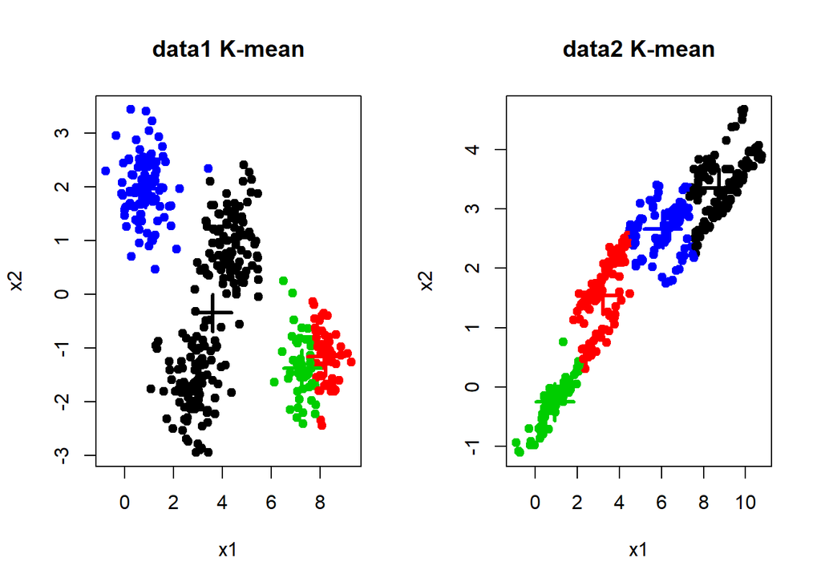

```r
par(mfrow=c(1,2))

x=data1[,1]
y=data1[,2]

plot(x,y,col=kmeanData1$cluster,pch=19, xlab="x1", ylab="x2")
points(kmeanData1$centers,col=1:4,pch=3,cex=3,lwd=3, title("data1 K-mean"))

x=data2[,1]
y=data2[,2]
plot(x,y,col=kmeanData2$cluster,pch=19, xlab="x1", ylab="x2")
points(kmeanData2$centers,col=1:4,pch=3,cex=3,lwd=3, title("data2 K-mean"))
```

### Question 3

3. Now fit a GMM model on the datasets. To do so, load the mclust library. Then you can use the function Mclust() on your data (this function will choose automatically the number of mixtures, basing on BIC criterion). Use the clustering results from your GMM model to visualize the results on both of the datasets, color the observations with respect to the clusters obtained from the GMM model. Interpret the results.

```r
library(mclust)
mclust_data1=Mclust(data1)
mclust_data2=Mclust(data2)

"Mclust of data1"
```

```
## [1] "Mclust of data1"
```

```r
mclust_data1
```

```
## 'Mclust' model object: (EII,4)
##
## Available components:
##  [1] "call"           "data"           "modelName"      "n"
##  [5] "d"              "G"              "BIC"            "loglik"
##  [9] "df"             "bic"            "icl"            "hypvol"
## [13] "parameters"     "z"              "classification" "uncertainty"
```

```r
"Mclust of data2"
```

```
## [1] "Mclust of data2"
```

```r
mclust_data2
```

```
## 'Mclust' model object: (EEE,4)
##
## Available components:
##  [1] "call"           "data"           "modelName"      "n"
##  [5] "d"              "G"              "BIC"            "loglik"
##  [9] "df"             "bic"            "icl"            "hypvol"
## [13] "parameters"     "z"              "classification" "uncertainty"
```

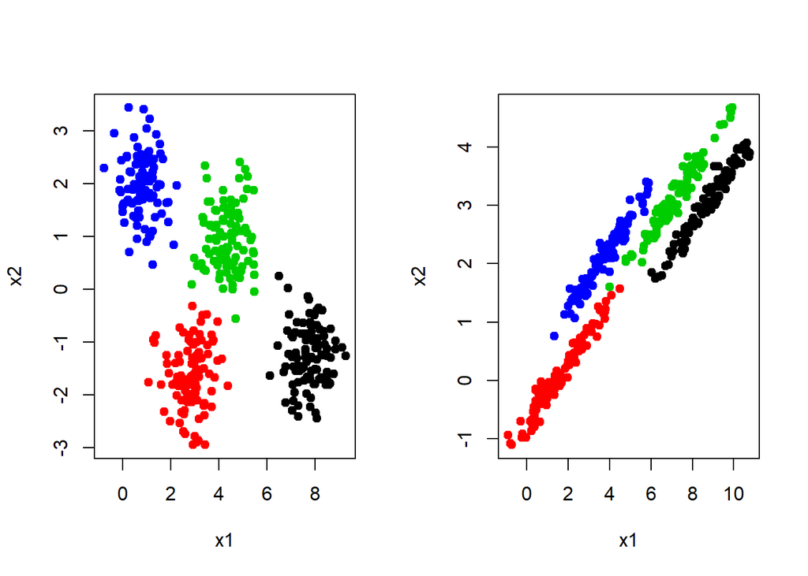

```r
par(mfrow=c(1,2))

x=data1[,1]
y=data1[,2]
plot(x,y,col=mclust_data1$classification,pch=19, xlab="x1", ylab="x2")


x=data2[,1]
y=data2[,2]
plot(x,y,col=mclust_data2$classification,pch=19, xlab="x1", ylab="x2")
```

### Question 4

4. Show the summary of the GMM model you fitted on Data2. Explain what it shows.

```r
summary(mclust_data2)
```

```
## ----------------------------------------------------
## Gaussian finite mixture model fitted by EM algorithm
## ----------------------------------------------------
##
## Mclust EEE (ellipsoidal, equal volume, shape and orientation) model with 4
## components:
##
##  log-likelihood   n df       BIC       ICL
##       -938.8639 400 14 -1961.608 -1965.709
##
## Clustering table:
##   1   2   3   4
## 100  99 101 100
```

### Question 5

5. mclust package offers some visualization. To plot your two-dimensional data, use the standard plot function applied on your model. Apply the following code, given that the model is named gmm_model, and interpret what it shows.

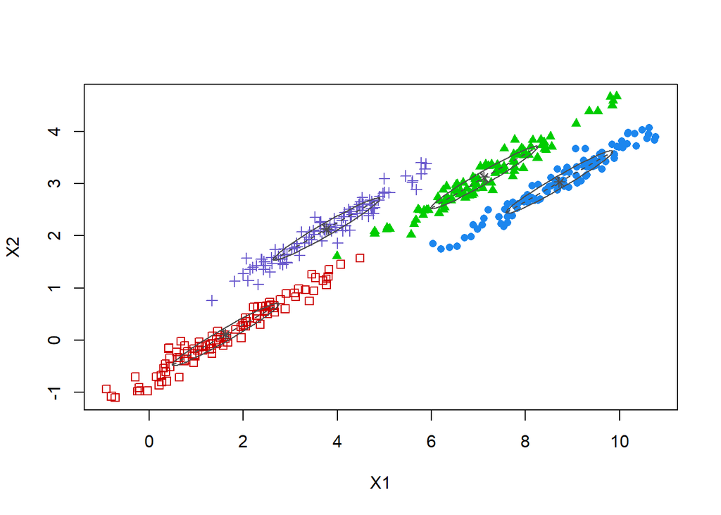

```r
plot(mclust_data2, what = "classification")
```

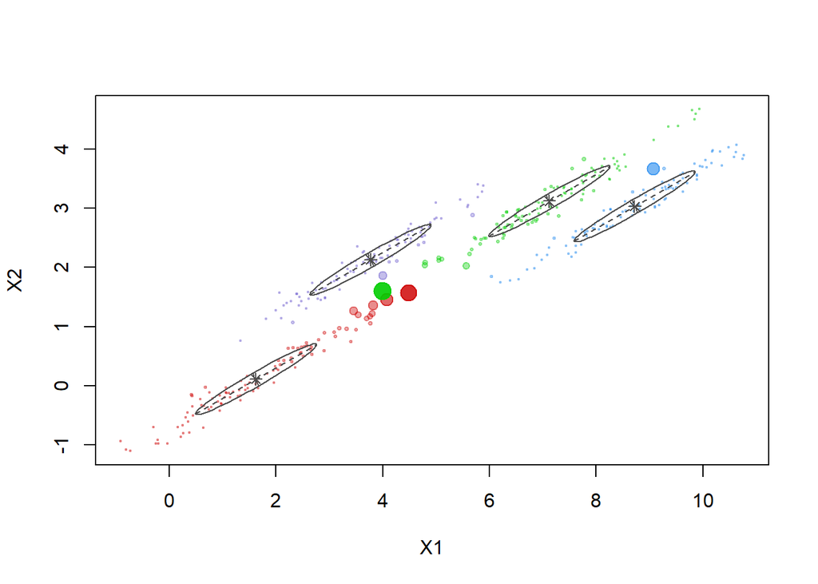

```r
plot(mclust_data2, what = "uncertainty")
```

### Question 6

6. mclust package uses the Bayesian Information Criterion (BIC) to choose the best number of mixtures. To see the values of BIC for different number of mixtures use the following code.

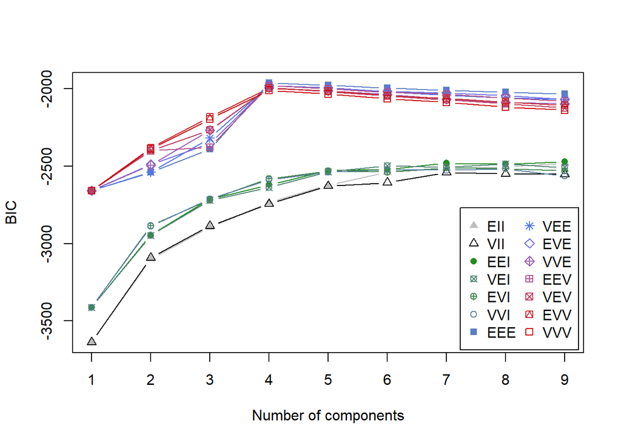

```r
plot(mclust_data2, what = "BIC")
```

### Question 7

7. Though GMM is often categorized as a clustering algorithm, fundamentally it is an algorithm for density estimation. That is to say, the result of a GMM fit to some data is technically not a clustering model, but a generative probabilistic model describing the distribution of the data. Density estimation plays an important role in applied statistical data analysis and theoretical research. A density estimate based on GMM can be obtained using the function densityMclust(). Apply it on Data2 and visualize the estimated densities (show an “image” and a “perspective” plot of the bivariate density estimate).

```r
densityData2 = densityMclust(data=data2)
densityData2
```

```
## 'densityMclust' model object: (EEE,4)
##
## Available components:
##  [1] "call"           "data"           "modelName"      "n"
##  [5] "d"              "G"              "BIC"            "loglik"
##  [9] "df"             "bic"            "icl"            "hypvol"
## [13] "parameters"     "z"              "classification" "uncertainty"
## [17] "density"
```

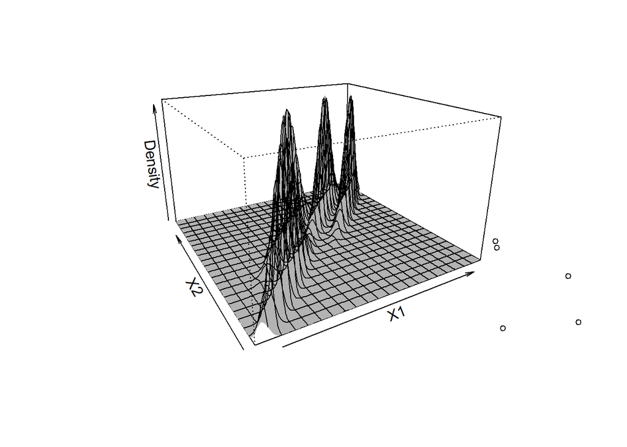

```r
plot(densityData2, what = "density", data = data2, type = "persp")
```

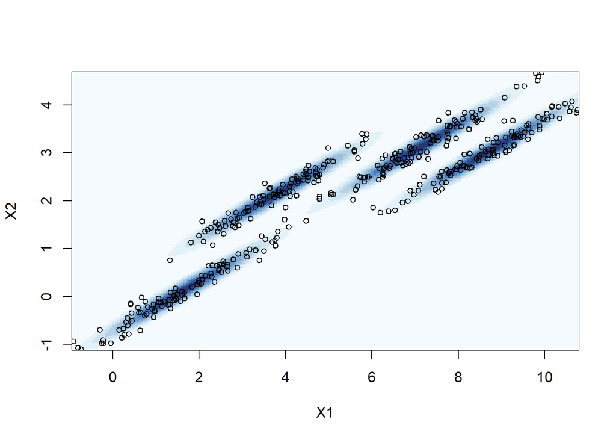

```r
plot(densityData2, what = "density", data = data2, type = "image")
```

## EM on 1D

### Question 8

```r
set.seed(123)

x1 = rnorm(100,-5)
x2 = rnorm(100,0)
x3 = rnorm(100,5)
source1 = rep(1,100)
source2 = rep(2,100)
source3 = rep(3,100)
sim.data = rbind(cbind(x1,source1),cbind(x2,source2),cbind(x3,source3))

head(sim.data)
```

```
##             x1 source1
## [1,] -5.560476       1
## [2,] -5.230177       1
## [3,] -3.441292       1
## [4,] -4.929492       1
## [5,] -4.870712       1
## [6,] -3.284935       1
```

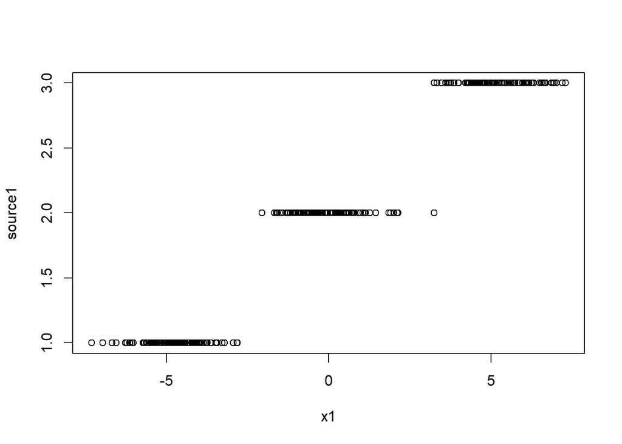

```r
plot(sim.data)
```

### Question 9

9. Show you generated data on one axe (this kind of figures are called stripchart), color them with respect to ground truth, you must obtain something like:

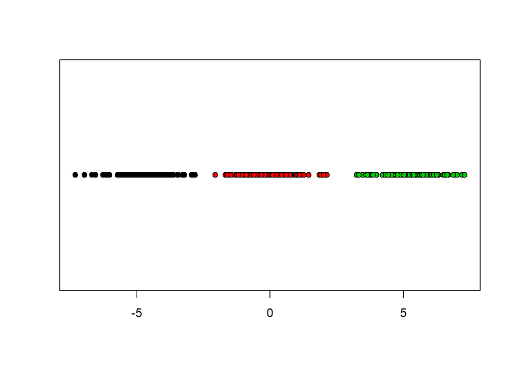

```r
cols = ifelse(sim.data[,2] == 1, "blue", ifelse(sim.data[,2] == 2, "green", "red"))
stripchart(sim.data[,1], bg=sim.data[,2], pch=21)
```

### Question 10

10. Plot the histogram corresponding to your generated data. Interpret it.

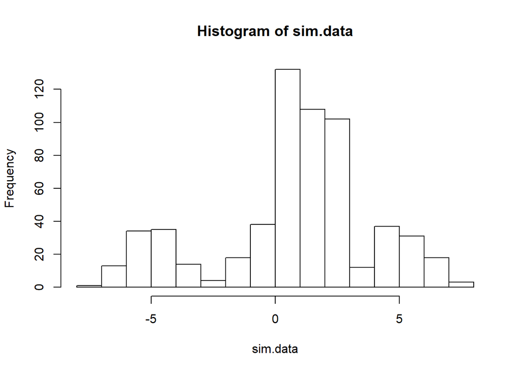

```r
hist(sim.data)
```

We can observe the 3 clusters.

### Question 11

11. Fit a GMM model on your generated data. Print the summary and visualize your results. Explain your results.

```r
sim.data.GMM <- Mclust(sim.data)
summary(sim.data.GMM)
```

```
## ----------------------------------------------------
## Gaussian finite mixture model fitted by EM algorithm
## ----------------------------------------------------
##
## Mclust VEV (ellipsoidal, equal shape) model with 2 components:
##
##  log-likelihood   n df       BIC       ICL
##       -514.1265 300 10 -1085.291 -1087.325
##
## Clustering table:
##   1   2
## 200 100
```

### Question 12

12. Apply a density estimate on your generated data and visualize it. Interpret the obtained figure.

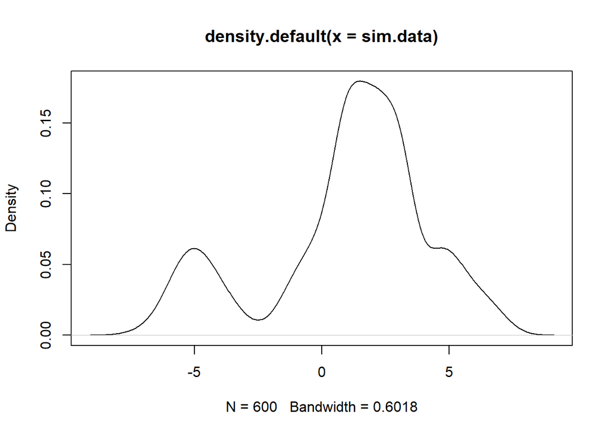

```r
dens <- density(sim.data)
plot(dens)
```